# Homework 7

Jess Wikle

2/26/2020

# Creating Fake Data Sets to Explore Hypotheses

##### 1. Go back to your “thinking on paper” exercise, and decide on a pattern that you might expect in your experiment if a specific hypothesis were true

I’m looking broadly at forest stand structure in an experiment designed to test strategies for forest climate change adaptation. For this assignment I’m looking at post-harvest aboveground biomass of trees and downed woody material in 3 treatments on a disturbance spectrum as well as an uncut control.

##### 3. Using the methods we have covered in class, write code to create a random dataset that has these attributes. Organize these data into a dataframe with the appropriate structure

```r
# all treatments have 40 plots
# control treatment has plot mean of 175 Mg/ha, minimal variability
CT <- rnorm(40, mean = 175, sd = 15)
CT <- data.frame(CT, "CT")
colnames(CT) <- c("agb_Mg", "treatment")
# resistance treatment has lower mean, still low variability
RT <- rnorm(40, mean = 160, sd = 20)
RT <- data.frame(RT, "RT")
colnames(RT) <- c("agb_Mg", "treatment")
# resilience treatment has lower mean, and higher variability
RL <- rnorm(40, mean = 150, sd = 35)
RL <- data.frame(RL, "RL")
colnames(RL) <- c("agb_Mg", "treatment")
# transition has lowest biomass, and most variability
TR <- rnorm(40, mean = 135, sd = 50)
TR <- data.frame(TR, "TR")
colnames(TR) <- c("agb_Mg", "treatment")
id <- c(1:160)
my_data <- rbind(CT, RT, RL, TR)
my_data <- cbind(id, my_data)

head(my_data)
```

```
##   id   agb_Mg treatment
## 1  1 192.3678        CT
## 2  2 151.2576        CT
## 3  3 148.0731        CT
## 4  4 156.4864        CT
## 5  5 167.7697        CT
## 6  6 197.5970        CT
```

```r
tail(my_data)
```

```
##      id    agb_Mg treatment
## 155 155 223.47587        TR
## 156 156 125.32710        TR
## 157 157 133.59276        TR
## 158 158  96.76817        TR
## 159 159 135.18014        TR
## 160 160 232.22714        TR
```

##### 4. Now write code to analyze the data. Write code to generate a useful plot of the data

```r
# categorical x (treatment) and continuous y (biomass) indicates ANOVA

m1 <- aov(agb_Mg ~ treatment, data = my_data)
summary(m1)
```

```
##              Df Sum Sq Mean Sq F value  Pr(>F)
## treatment     3  19062    6354   4.926 0.00269 **
## Residuals   156 201243    1290
## ---
## Signif. codes:  0 '***' 0.001 '**' 0.01 '*' 0.05 '.' 0.1 ' ' 1
```

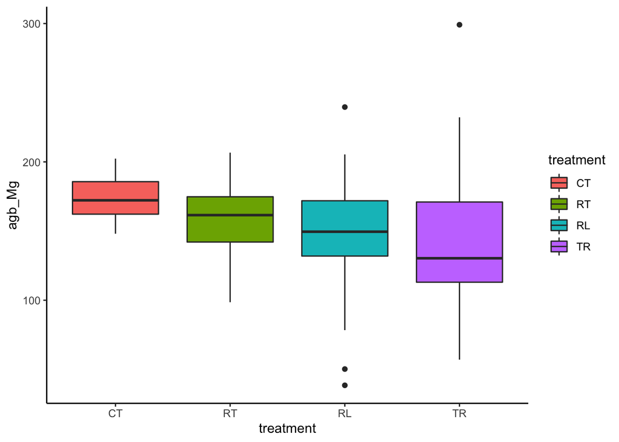

```r
library(ggplot2)
p1 <- ggplot(data = my_data, aes(x = treatment,
                                        y = agb_Mg,
                                        fill = treatment)) +
  geom_boxplot() +
  theme_classic()
p1
```

##### 5. Try running your analysis multiple times to get a feeling for how variable the results are within the same parameters, but different sets of random numbers

5 repetitions

```
##              Df Sum Sq Mean Sq F value   Pr(>F)
## treatment     3  24088    8029   8.663 2.36e-05 ***
## Residuals   156 144589     927
## ---
## Signif. codes:  0 '***' 0.001 '**' 0.01 '*' 0.05 '.' 0.1 ' ' 1
```

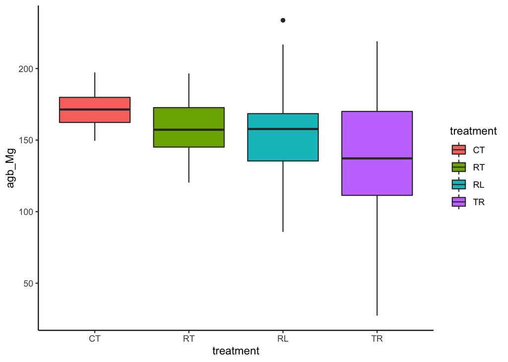

```
##              Df Sum Sq Mean Sq F value   Pr(>F)
## treatment     3  45197   15066   13.98 4.06e-08 ***
## Residuals   156 168143    1078
## ---
## Signif. codes:  0 '***' 0.001 '**' 0.01 '*' 0.05 '.' 0.1 ' ' 1
```

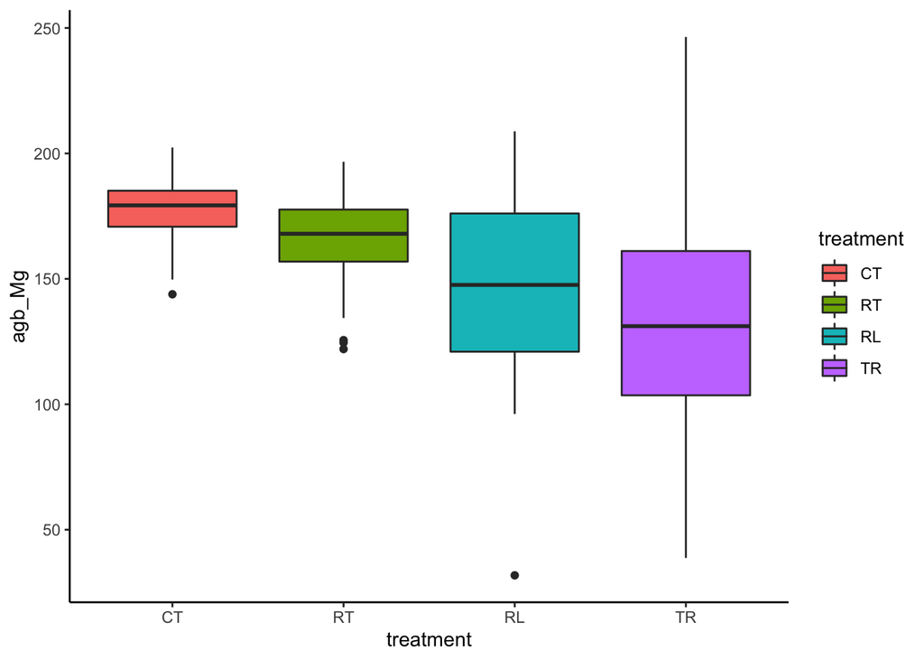

```
##              Df Sum Sq Mean Sq F value   Pr(>F)
## treatment     3  35132   11711   13.34 8.57e-08 ***
## Residuals   156 136999     878
## ---
## Signif. codes:  0 '***' 0.001 '**' 0.01 '*' 0.05 '.' 0.1 ' ' 1
```

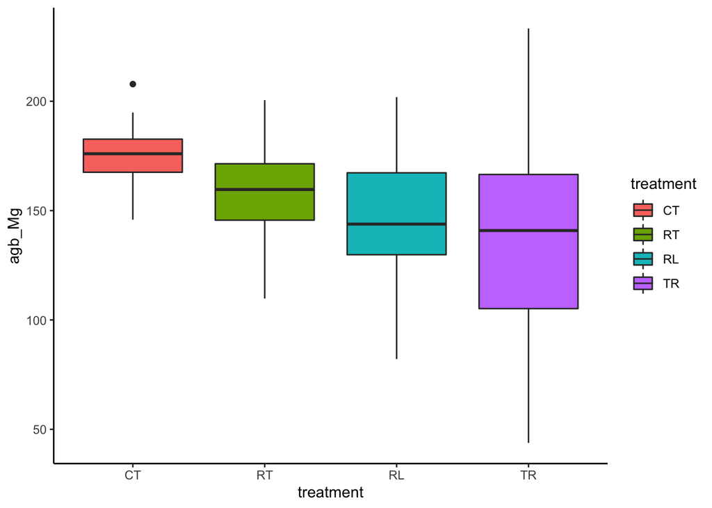

```
##              Df Sum Sq Mean Sq F value   Pr(>F)
## treatment     3  31290   10430   10.16 3.77e-06 ***
## Residuals   156 160181    1027
## ---
## Signif. codes:  0 '***' 0.001 '**' 0.01 '*' 0.05 '.' 0.1 ' ' 1
```

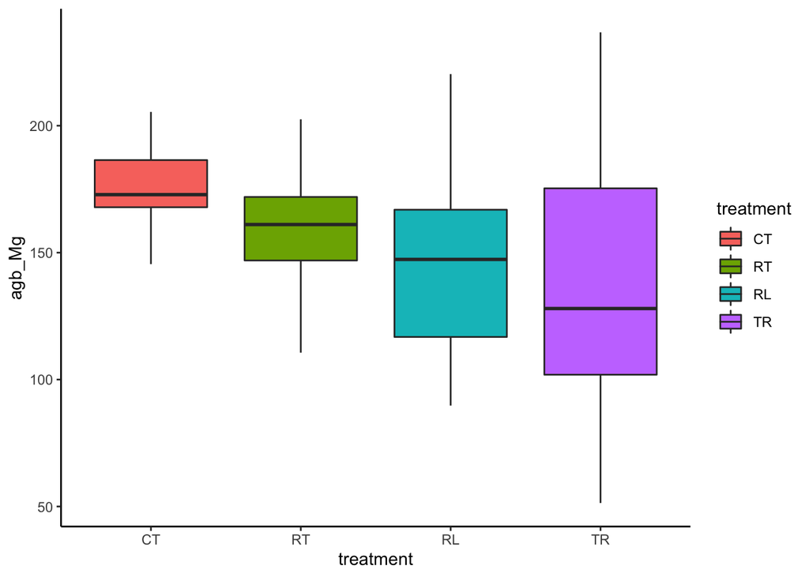

```
##              Df Sum Sq Mean Sq F value   Pr(>F)
## treatment     3  83300   27767   25.45 1.86e-13 ***
## Residuals   156 170207    1091
## ---
## Signif. codes:  0 '***' 0.001 '**' 0.01 '*' 0.05 '.' 0.1 ' ' 1
```

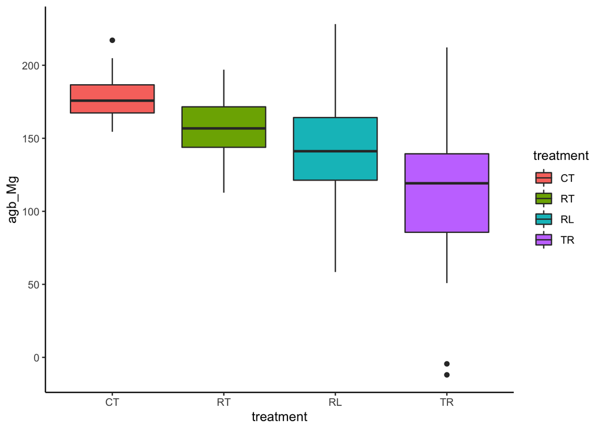

#### 6. Now begin adjusting the means of the different groups. Given the sample sizes you have chosen, how small can the differences between the groups be (the “effect size”) for you to still detect a significant pattern (p < 0.05)

```r
# Converging on mean of 155
CT <- rnorm(40, mean = 170, sd = 15)
CT <- data.frame(CT, "CT")
colnames(CT) <- c("agb_Mg", "treatment")
RT <- rnorm(40, mean = 155, sd = 20)
RT <- data.frame(RT, "RT")
colnames(RT) <- c("agb_Mg", "treatment")
RL <- rnorm(40, mean = 155, sd = 35)
RL <- data.frame(RL, "RL")
colnames(RL) <- c("agb_Mg", "treatment")
TR <- rnorm(40, mean = 140, sd = 50)
TR <- data.frame(TR, "TR")
colnames(TR) <- c("agb_Mg", "treatment")
id <- c(1:160)
my_data <- rbind(CT, RT, RL, TR)
my_data <- cbind(id, my_data)
m1 <- aov(agb_Mg ~ treatment, data = my_data)
summary(m1)
```

```
##              Df Sum Sq Mean Sq F value   Pr(>F)
## treatment     3  20963    6988   6.367 0.000424 ***
## Residuals   156 171194    1097
## ---
## Signif. codes:  0 '***' 0.001 '**' 0.01 '*' 0.05 '.' 0.1 ' ' 1
```

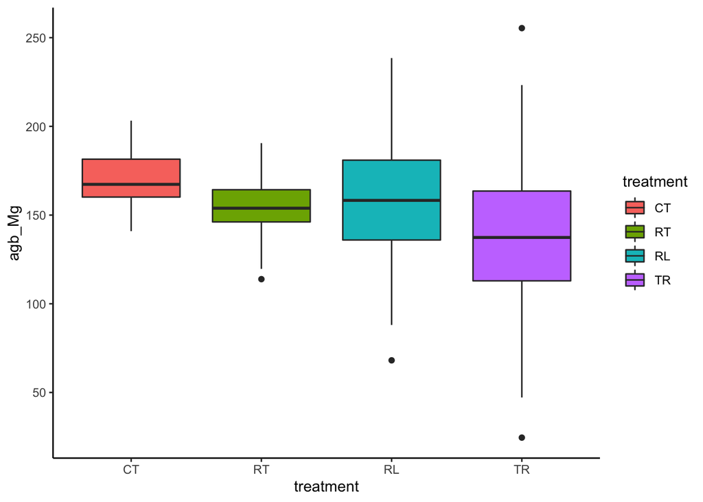

```r
p1 <- ggplot(data = my_data, aes(x = treatment,
                                        y = agb_Mg,
                                        fill = treatment)) +
  geom_boxplot() +
  theme_classic()
p1
```

Still significant

```r
# Converging on mean of 155
CT <- rnorm(40, mean = 160, sd = 15)
CT <- data.frame(CT, "CT")
colnames(CT) <- c("agb_Mg", "treatment")
RT <- rnorm(40, mean = 155, sd = 20)
RT <- data.frame(RT, "RT")
colnames(RT) <- c("agb_Mg", "treatment")
RL <- rnorm(40, mean = 155, sd = 35)
RL <- data.frame(RL, "RL")
colnames(RL) <- c("agb_Mg", "treatment")
TR <- rnorm(40, mean = 150, sd = 50)
TR <- data.frame(TR, "TR")
colnames(TR) <- c("agb_Mg", "treatment")
id <- c(1:160)
my_data <- rbind(CT, RT, RL, TR)
my_data <- cbind(id, my_data)
m1 <- aov(agb_Mg ~ treatment, data = my_data)
summary(m1)
```

```
##              Df Sum Sq Mean Sq F value Pr(>F)
## treatment     3   3319    1106   0.951  0.418
## Residuals   156 181550    1164
```

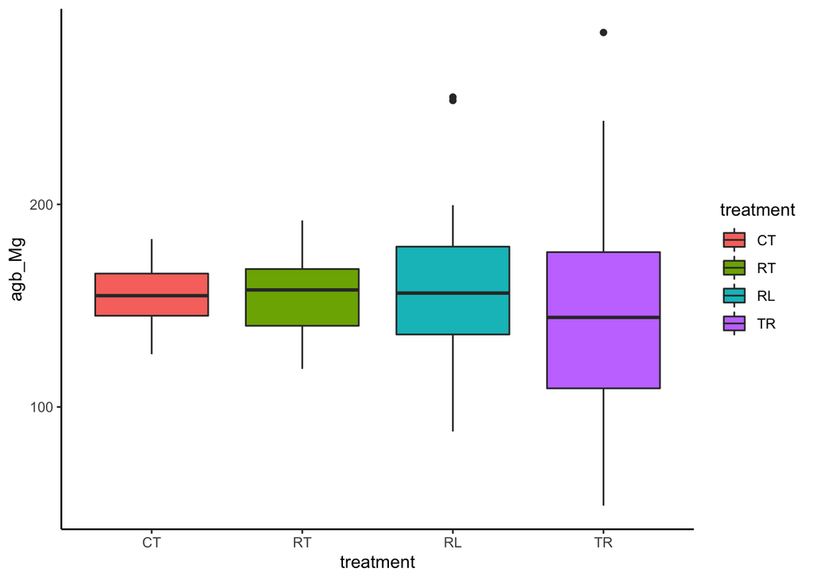

```r
p1 <- ggplot(data = my_data, aes(x = treatment,
                                        y = agb_Mg,
                                        fill = treatment)) +
  geom_boxplot() +
  theme_classic()
p1
```

Significant 5/30 times

#### 7. Alternatively, for the effect sizes you originally hypothesized, what is the minimum sample size you would need in order to detect a statistically significant effect?

```r
# drop down to sample size of 30
CT <- rnorm(30, mean = 170, sd = 15)
CT <- data.frame(CT, "CT")
colnames(CT) <- c("agb_Mg", "treatment")
RT <- rnorm(30, mean = 155, sd = 20)
RT <- data.frame(RT, "RT")
colnames(RT) <- c("agb_Mg", "treatment")
RL <- rnorm(30, mean = 155, sd = 35)
RL <- data.frame(RL, "RL")
colnames(RL) <- c("agb_Mg", "treatment")
TR <- rnorm(30, mean = 140, sd = 50)
TR <- data.frame(TR, "TR")
colnames(TR) <- c("agb_Mg", "treatment")
id <- c(1:120)
my_data <- rbind(CT, RT, RL, TR)
my_data <- cbind(id, my_data)
m1 <- aov(agb_Mg ~ treatment, data = my_data)
summary(m1)
```

```
##              Df Sum Sq Mean Sq F value   Pr(>F)
## treatment     3  18678    6226   6.633 0.000356 ***
## Residuals   116 108885     939
## ---
## Signif. codes:  0 '***' 0.001 '**' 0.01 '*' 0.05 '.' 0.1 ' ' 1
```

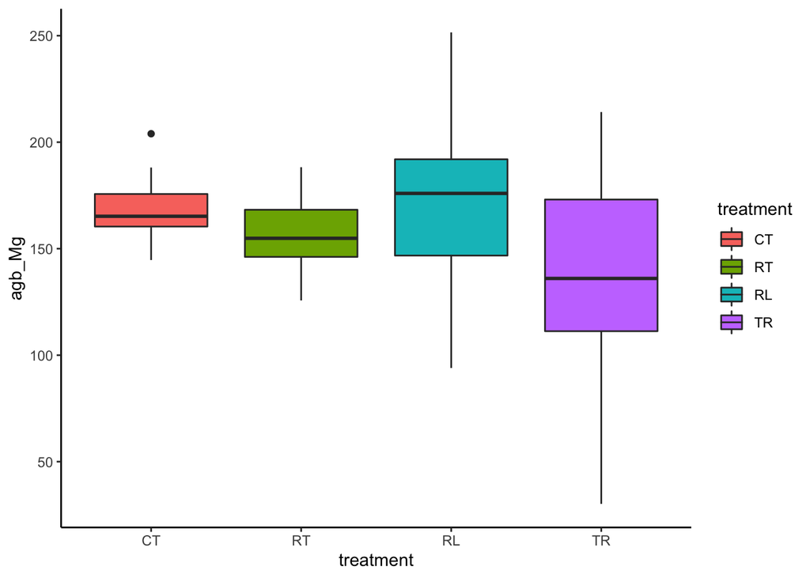

```r
p1 <- ggplot(data = my_data, aes(x = treatment,
                                        y = agb_Mg,
                                        fill = treatment)) +
  geom_boxplot() +
  theme_classic()
p1
```

Significant 24/30 tries

```r
# drop down to sample size of 20
CT <- rnorm(20, mean = 170, sd = 15)
CT <- data.frame(CT, "CT")
colnames(CT) <- c("agb_Mg", "treatment")
RT <- rnorm(20, mean = 155, sd = 20)
RT <- data.frame(RT, "RT")
colnames(RT) <- c("agb_Mg", "treatment")
RL <- rnorm(20, mean = 155, sd = 35)
RL <- data.frame(RL, "RL")
colnames(RL) <- c("agb_Mg", "treatment")
TR <- rnorm(20, mean = 140, sd = 50)
TR <- data.frame(TR, "TR")
colnames(TR) <- c("agb_Mg", "treatment")
id <- c(1:80)
my_data <- rbind(CT, RT, RL, TR)
my_data <- cbind(id, my_data)
m1 <- aov(agb_Mg ~ treatment, data = my_data)
summary(m1)
```

```
##             Df Sum Sq Mean Sq F value Pr(>F)
## treatment    3   6410  2136.5   3.115 0.0311 *
## Residuals   76  52125   685.9
## ---
## Signif. codes:  0 '***' 0.001 '**' 0.01 '*' 0.05 '.' 0.1 ' ' 1
```

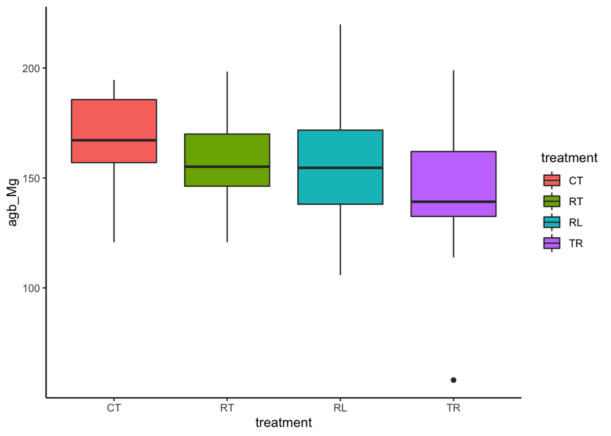

```r
p1 <- ggplot(data = my_data, aes(x = treatment,
                                        y = agb_Mg,
                                        fill = treatment)) +
  geom_boxplot() +
  theme_classic()
p1
```

Significant 14/30 tries

```r
# drop down to sample size of 10
CT <- rnorm(10, mean = 170, sd = 15)
CT <- data.frame(CT, "CT")
colnames(CT) <- c("agb_Mg", "treatment")
RT <- rnorm(10, mean = 155, sd = 20)
RT <- data.frame(RT, "RT")
colnames(RT) <- c("agb_Mg", "treatment")
RL <- rnorm(10, mean = 155, sd = 35)
RL <- data.frame(RL, "RL")
colnames(RL) <- c("agb_Mg", "treatment")
TR <- rnorm(10, mean = 140, sd = 50)
TR <- data.frame(TR, "TR")
colnames(TR) <- c("agb_Mg", "treatment")
id <- c(1:40)
my_data <- rbind(CT, RT, RL, TR)
my_data <- cbind(id, my_data)
m1 <- aov(agb_Mg ~ treatment, data = my_data)
summary(m1)
```

```
##             Df Sum Sq Mean Sq F value Pr(>F)
## treatment    3   5427    1809   1.751  0.174
## Residuals   36  37204    1033
```

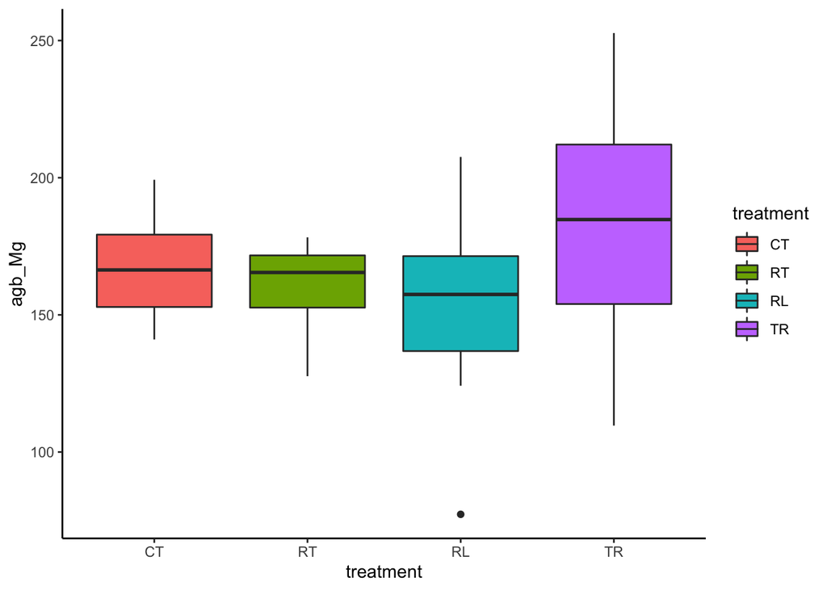

```r
p1 <- ggplot(data = my_data, aes(x = treatment,
                                        y = agb_Mg,
                                        fill = treatment)) +
  geom_boxplot() +
  theme_classic()
p1
```

Significant only 6/30 times (still surprising for such a decrease in sample size!)